# Build a tissue-clock from histopathology features

## Cross-validated ridge regression per organ

- Grouped 5-fold CV on `Subject ID` to avoid leakage across slides from the same donor.
- Standardize features inside the pipeline.
- Save per-organ predictions and a diagnostic scatter plot.

```
  0%|                                                                                                                                                                | 0/4 [00:00<?, ?it/s]
```

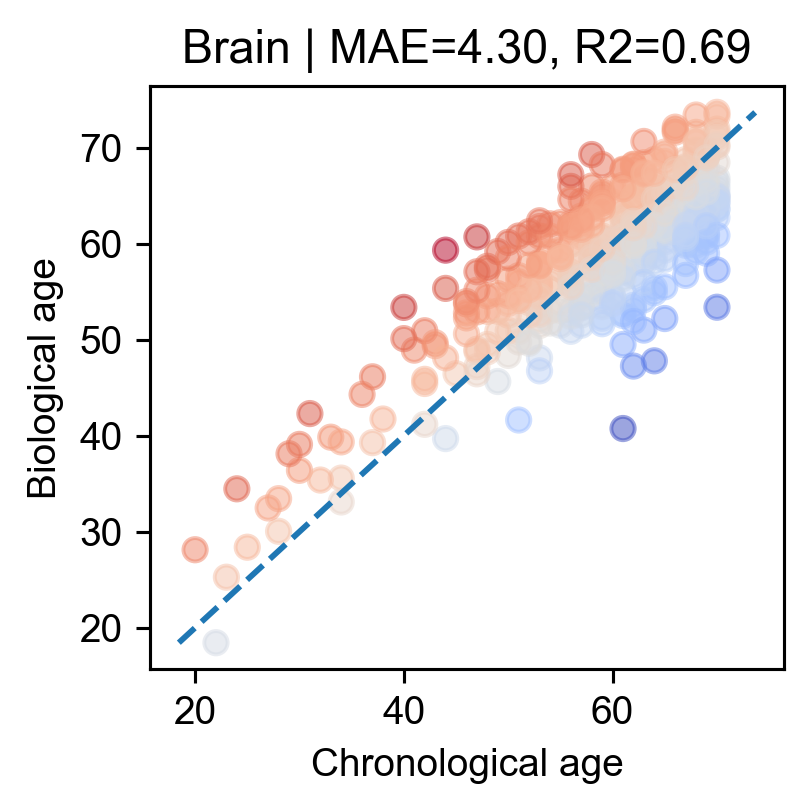

```
 25%|██████████████████████████████████████                                                                                                                  | 1/4 [00:03<00:11,  3.87s/it]
```

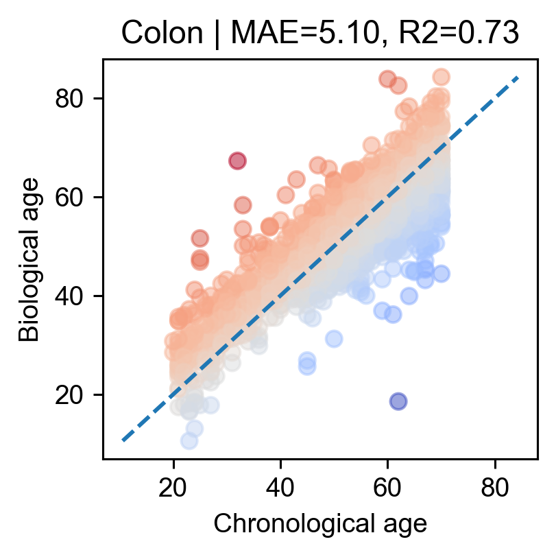

```
 50%|████████████████████████████████████████████████████████████████████████████                                                                            | 2/4 [00:16<00:18,  9.20s/it]
```

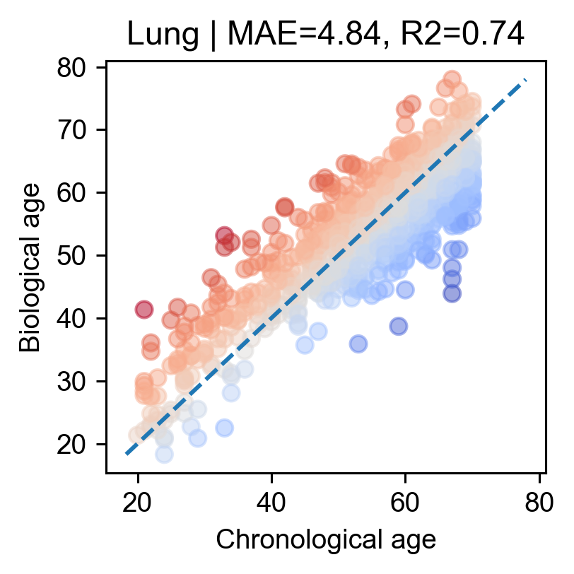

```
 75%|██████████████████████████████████████████████████████████████████████████████████████████████████████████████████                                      | 3/4 [00:22<00:07,  7.43s/it]
```

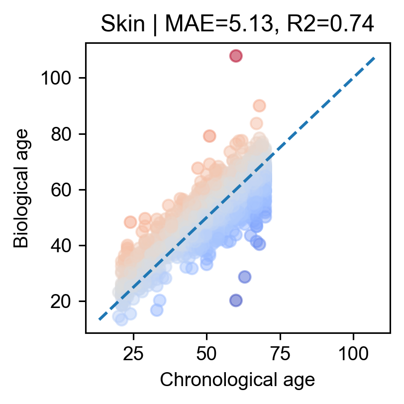

```
100%|████████████████████████████████████████████████████████████████████████████████████████████████████████████████████████████████████████████████████████| 4/4 [00:35<00:00,  8.99s/it]
```

|  | Organ | n | p | MAE | R2 |
| --- | --- | --- | --- | --- | --- |
| 0 | Lung | 850 | 2560 | 4.836514 | 0.741046 |
| 1 | Skin | 1798 | 2560 | 5.125410 | 0.735488 |
| 2 | Colon | 1720 | 2560 | 5.100208 | 0.732343 |
| 3 | Brain | 423 | 2560 | 4.303720 | 0.689260 |

```python
from sklearn.model_selection import GroupKFold, cross_val_predict
from sklearn.pipeline import make_pipeline
from sklearn.linear_model import RidgeCV
from sklearn.preprocessing import StandardScaler
from sklearn.metrics import r2_score, mean_absolute_error
import matplotlib.pyplot as plt
from tqdm import tqdm

def fit_cv_per_organ(a, outdir: Path, model_name: str, mpp: float, tile_width: int):
    outdir.mkdir(parents=True, exist_ok=True)
    suffix = f".{mpp}mpp.{tile_width}px.{model_name}"
    cv = GroupKFold(5)

    organs = sorted(a.obs["Organ"].unique())
    summary_rows = []

    for organ in tqdm(organs):
        _a = a[a.obs["Organ"] == organ]

        # Aggregate per slide ID if the matrix has multi-index columns. If already per-slide, take as-is.
        X = _a.to_df()
        if isinstance(X.index, pd.MultiIndex):
            X = X.groupby(level=0).mean()

        # Align y (Age) to X
        y = _a.obs.reindex(X.index)["Age"]
        groups = _a.obs.reindex(X.index)["Subject ID"]

        alphas = np.logspace(-2, 3, 20)
        ridgecv = RidgeCV(alphas=alphas, fit_intercept=True)
        model = make_pipeline(StandardScaler(with_mean=True, with_std=True), ridgecv)

        y_pred = cross_val_predict(model, X, y, cv=cv, groups=groups, n_jobs=-1)
        r2 = r2_score(y, y_pred)
        mae = mean_absolute_error(y, y_pred)

        # Save predictions
        pred_df = pd.DataFrame({"y_true": y, "y_pred": y_pred, "age_gap": y_pred - y})
        pred_path = outdir / f"ridgecv{suffix}.{organ}.csv"
        pred_df.to_csv(pred_path, index=True)

        # Plot
        vmin, vmax = pd.Series(pd.concat([y, pd.Series(y_pred, index=y.index)])).agg(["min", "max"]).values
        fig, ax = plt.subplots(figsize=FIGSIZE, dpi=DPI)
        error = y_pred - y
        ax.plot([vmin, vmax], [vmin, vmax], linestyle="--")
        ax.scatter(y, y_pred, alpha=0.5, c=error, cmap='coolwarm')
        ax.set(xlabel="Chronological age", ylabel="Biological age", title=f"{organ} | MAE={mae:.2f}, R2={r2:.2f}")
        fig.tight_layout()
        fig.savefig(outdir / f"ridgecv{suffix}.{organ}.png", dpi=DPI)
        plt.show(fig)

        summary_rows.append({"Organ": organ, "n": len(y), "p": X.shape[1], "MAE": mae, "R2": r2})

    return pd.DataFrame(summary_rows).sort_values(["R2", "MAE"], ascending=[False, True]).reset_index(drop=True)

clock_outdir = results_dir / "clock_cv_only"
summary = fit_cv_per_organ(adata, clock_outdir, model_name=model_name, mpp=mpp, tile_width=tile_width)
summary_path = clock_outdir / f"summary.{mpp}mpp.{tile_width}px.{model_name}.csv"
summary.to_csv(summary_path, index=False)
summary
```

## Inspect predictions for a specific organ

```python
# Choose the top-performing organ (if any), else fall back to the first available
if len(summary):
    organ_pick = summary.iloc[0]["Organ"]
    print("Inspecting organ:", organ_pick)

    suffix = f".{mpp}mpp.{tile_width}px.{model_name}"
    pred_path = clock_outdir / f"ridgecv{suffix}.{organ_pick}.csv"
    pred_df = pd.read_csv(pred_path, index_col=0)
    pred_df.head()
else:
    print("No organs available for inspection (likely synthetic or minimal data).")
```

```
Inspecting organ: Lung
```

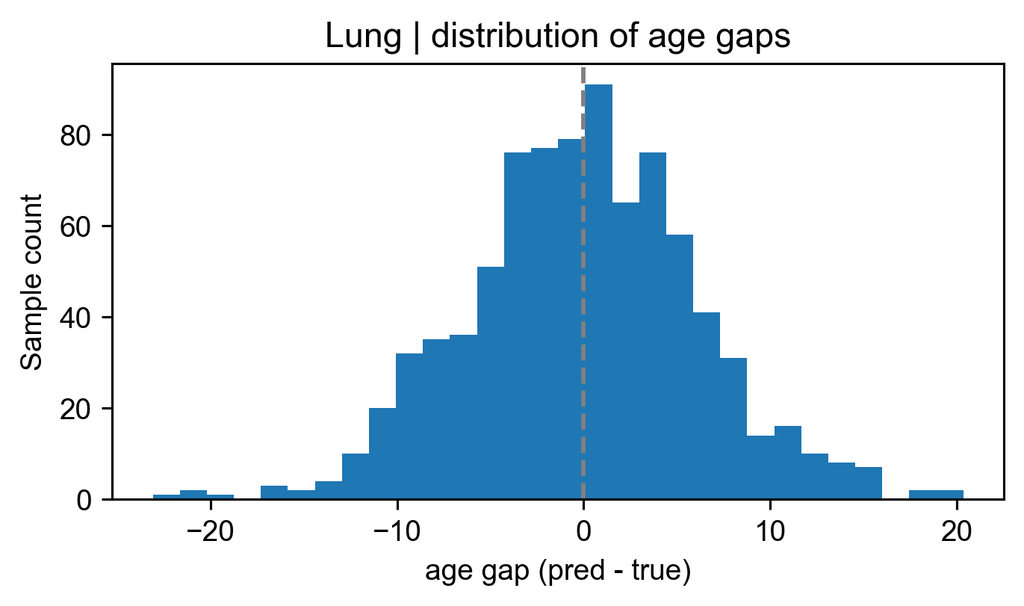

```python
fig, ax = plt.subplots(figsize=(5, 3), dpi=DPI)
ax.axvline(0, linestyle='--', color='grey')
ax.hist(pred_df["age_gap"], bins=30)
ax.set(xlabel="age gap (pred - true)", ylabel="Sample count", title=f"{organ_pick} | distribution of age gaps")
fig.tight_layout()
```

## Notes and next steps

- This notebook intentionally **does not** fit a final model or export scalers/coefficients.
- To stabilize and interpret models further you might:
  - Add **covariates** (e.g., ischemic time) and perform residualization prior to CV.
  - Explore regularization paths, nested CV, or robust regressors.
  - Compare different feature backbones (Virchow2, PRISM, TITAN, etc.).
  - Evaluate **cross-cohort** transfer by applying clocks trained in one dataset to another.
- For mechanistic links, integrate matched RNA-seq to test pathway associations vs biological age gaps.